# Análise de Dados da Produção Agrícola de Minas Gerais

```r
#install.packages('tidyverse')
library('tidyverse')

#install.packages('ggplot2')
library('ggplot2')
```

## Base de dados

```r
#Dados sobre produção agricola (IBGE)
dados <- read.csv("base_exercicio3.csv", sep=";")
view(dados)
head(dados)
```

```
##    Cód. Microrregião.Geográfica  Ano Produto.das.lavouras.temporárias
## 1 31001               Unaí (MG) 2010     Algodão herbáceo (em caroço)
## 2 31001               Unaí (MG) 2010     Algodão herbáceo (em caroço)
## 3 31001               Unaí (MG) 2010     Algodão herbáceo (em caroço)
## 4 31001               Unaí (MG) 2010                             Alho
## 5 31001               Unaí (MG) 2010                             Alho
## 6 31001               Unaí (MG) 2010                             Alho
##                           Variável     X
## 1          Área colhida (Hectares)  4339
## 2 Quantidade produzida (Toneladas) 16922
## 3    Valor da produção (Mil Reais) 20306
## 4          Área colhida (Hectares)    40
## 5 Quantidade produzida (Toneladas)   600
## 6    Valor da produção (Mil Reais)   600
```

## Descobrindo um pouco mais sobre os dados

### Nome das colunas

```r
#entao (pip) do r : ctrl+shift+m
#Nome das colunas
colnames(dados)
```

```
## [1] "Cód."                             "Microrregião.Geográfica"
## [3] "Ano"                              "Produto.das.lavouras.temporárias"
## [5] "Variável"                         "X"
```

Percebemos que os nomes tem letras maiúsculas e acentos. Por isso, vamos trocá-los.

```r
base <- dados %>% rename(
  microrregiao= "Microrregião.Geográfica",
  produto="Produto.das.lavouras.temporárias",
  variavel="Variável",
  cod="Cód." ,
  ano="Ano",
  x="X"
  )
```

### Descobrindo o tipo de dado de cada coluna

```r
class(base$ano)
```

```
## [1] "integer"
```

```r
class(base$cod)
```

```
## [1] "integer"
```

```r
class(base$microrregiao)
```

```
## [1] "character"
```

```r
class(base$produto)
```

```
## [1] "character"
```

```r
class(base$variavel)
```

```
## [1] "character"
```

```r
class(base$x)
```

```
## [1] "character"
```

Percebemos que a coluna “X” tem dados do tipo “character”. Porém, esta coluna tem números. Logo, precisamos modificar o tipo de dado.

```r
base <- base %>% mutate(
    x=as.numeric(x))
class(base$x)
```

```
## [1] "numeric"
```

Além disso, vamos trocar as NA’s por 0.E em seguida, vamos salvar todas as modificações como uma nova base de dados em csv

```r
base <- base %>% mutate_all(replace_na,0) %>% write.csv2(
  file='base.csv'
)

#write.csv2 : estamos salvando esta tabela num csv
```

Vamos checar se foi gerado o arquivo csv

```r
dir()
```

```
## [1] "base.csv"                           "base_exercicio3.csv"
## [3] "base_imposto.csv"                   "controle.r"
## [5] "exercicio_sidra.r"                  "exercicio3.r"
## [7] "Projeto1-Producao_agricola_MG.html" "Projeto1-Producao_agricola_MG.rmd"
## [9] "ranking_produto.csv"
```

Importar a nova base de dados

```r
base <- read.csv2('base.csv')

#Verificar os nomes das colunas da base de dados
colnames(base)
```

```
## [1] "X"            "cod"          "microrregiao" "ano"          "produto"
## [6] "variavel"     "x"
```

```r
#Visualização dos dados
view(base)
```

## Coluna “Variável”

Dentro desta coluna existem três categorias:“Área colhida (Hectares)”, “Quantidade produzida (Toneladas)”,“Valor da produção (Mil Reais)”.  
O objetivo agora será separar cada categoria numa tabela diferente.

### Área colhida: seleção da variável “Área colhida(hectares)” e criação de uma nova tabela

```r
area_colhida <- base %>% filter(variavel == 'Área colhida (Hectares)')

view(area_colhida)

head(area_colhida, n=10)
```

```
##     X   cod microrregiao  ano                      produto
## 1   1 31001    Unaí (MG) 2010 Algodão herbáceo (em caroço)
## 2   4 31001    Unaí (MG) 2010                         Alho
## 3   7 31001    Unaí (MG) 2010          Amendoim (em casca)
## 4  10 31001    Unaí (MG) 2010             Arroz (em casca)
## 5  13 31001    Unaí (MG) 2010              Aveia (em grão)
## 6  16 31001    Unaí (MG) 2010                  Batata-doce
## 7  19 31001    Unaí (MG) 2010               Batata-inglesa
## 8  22 31001    Unaí (MG) 2010               Cana-de-açúcar
## 9  25 31001    Unaí (MG) 2010                       Cebola
## 10 28 31001    Unaí (MG) 2010            Centeio (em grão)
##                   variavel    x
## 1  Área colhida (Hectares) 4339
## 2  Área colhida (Hectares)   40
## 3  Área colhida (Hectares)   48
## 4  Área colhida (Hectares) 2110
## 5  Área colhida (Hectares)    0
## 6  Área colhida (Hectares)    0
## 7  Área colhida (Hectares)    0
## 8  Área colhida (Hectares)  514
## 9  Área colhida (Hectares)    0
## 10 Área colhida (Hectares)    0
```

### Quantidade produzida: seleção da variável “Quantidade produzida (Toneladas)” e criação de uma nova tabela

```r
quant_produzida <- base %>% filter(variavel== "Quantidade produzida (Toneladas)")

view(quant_produzida)

head(quant_produzida , n=10)
```

```
##     X   cod microrregiao  ano                      produto
## 1   2 31001    Unaí (MG) 2010 Algodão herbáceo (em caroço)
## 2   5 31001    Unaí (MG) 2010                         Alho
## 3   8 31001    Unaí (MG) 2010          Amendoim (em casca)
## 4  11 31001    Unaí (MG) 2010             Arroz (em casca)
## 5  14 31001    Unaí (MG) 2010              Aveia (em grão)
## 6  17 31001    Unaí (MG) 2010                  Batata-doce
## 7  20 31001    Unaí (MG) 2010               Batata-inglesa
## 8  23 31001    Unaí (MG) 2010               Cana-de-açúcar
## 9  26 31001    Unaí (MG) 2010                       Cebola
## 10 29 31001    Unaí (MG) 2010            Centeio (em grão)
##                            variavel     x
## 1  Quantidade produzida (Toneladas) 16922
## 2  Quantidade produzida (Toneladas)   600
## 3  Quantidade produzida (Toneladas)    84
## 4  Quantidade produzida (Toneladas)  2656
## 5  Quantidade produzida (Toneladas)     0
## 6  Quantidade produzida (Toneladas)     0
## 7  Quantidade produzida (Toneladas)     0
## 8  Quantidade produzida (Toneladas) 23410
## 9  Quantidade produzida (Toneladas)     0
## 10 Quantidade produzida (Toneladas)     0
```

### Valor da produção: seleção da variável “Valor da produção (Mil Reais)” e criação de uma nova tabela

```r
valor_producao <- base %>% filter (variavel == "Valor da produção (Mil Reais)")

view(valor_producao)

head(valor_producao , n=10)
```

```
##     X   cod microrregiao  ano                      produto
## 1   3 31001    Unaí (MG) 2010 Algodão herbáceo (em caroço)
## 2   6 31001    Unaí (MG) 2010                         Alho
## 3   9 31001    Unaí (MG) 2010          Amendoim (em casca)
## 4  12 31001    Unaí (MG) 2010             Arroz (em casca)
## 5  15 31001    Unaí (MG) 2010              Aveia (em grão)
## 6  18 31001    Unaí (MG) 2010                  Batata-doce
## 7  21 31001    Unaí (MG) 2010               Batata-inglesa
## 8  24 31001    Unaí (MG) 2010               Cana-de-açúcar
## 9  27 31001    Unaí (MG) 2010                       Cebola
## 10 30 31001    Unaí (MG) 2010            Centeio (em grão)
##                         variavel     x
## 1  Valor da produção (Mil Reais) 20306
## 2  Valor da produção (Mil Reais)   600
## 3  Valor da produção (Mil Reais)   252
## 4  Valor da produção (Mil Reais)  2320
## 5  Valor da produção (Mil Reais)     0
## 6  Valor da produção (Mil Reais)     0
## 7  Valor da produção (Mil Reais)     0
## 8  Valor da produção (Mil Reais)  1944
## 9  Valor da produção (Mil Reais)     0
## 10 Valor da produção (Mil Reais)     0
```

## Questionamentos:

### Ranking por microrregião

### 1. Quais produtos tiveram as maiores quantidades produzidas de alimento por microrregião?

Para responder esta pergunta, será criado um ranking da quantidade produzida (total) por microrregião.

```r
#Ranking por microrregião de todas as produções

# group_by é usado para agrupar os dados pela variável "microrregiao".  Isso significa que os dados serão divididos em grupos com base nos diferentes valores encontrados na coluna "microrregiao".

# summarise é usado para resumir os dados agrupados. Ele calculará a soma dos valores da variável "x" para cada grupo de microrregião. O resultado é armazenado em uma nova variável chamada "soma".

#Arrange é usado para ordenar os dados , neste caso em ordem decrescente (desc)

ranking_microrregiao <- quant_produzida %>% group_by(
  microrregiao) %>% summarise(soma=sum(x)) %>% arrange((desc(soma)))

view(ranking_microrregiao)
head(ranking_microrregiao)
```

```
## # A tibble: 6 × 2
##   microrregiao         soma
##   <chr>               <int>
## 1 Uberaba (MG)    196881157
## 2 Frutal (MG)     186052626
## 3 Uberlândia (MG)  79876439
## 4 Araxá (MG)       79045826
## 5 Paracatu (MG)    65161717
## 6 Ituiutaba (MG)   64651733
```

Uberaba,Frutal e Uberlandia são as três microrregiões que mais produzem alimentos em MG.

### 1.1 Qual produto é mais produzido em Uberaba?

```r
Uberaba_producao <- quant_produzida %>% filter( microrregiao == "Uberaba (MG)") %>% group_by(produto) %>% summarise(soma=sum(x)) %>% arrange(desc(soma))

#Visualizar os dados
view(Uberaba_producao)

#Visualizar os primeiros valores
head(Uberaba_producao, n=4)
```

```
## # A tibble: 4 × 2
##   produto              soma
##   <chr>               <int>
## 1 Cana-de-açúcar  184106207
## 2 Milho (em grão)   5382523
## 3 Soja (em grão)    5162432
## 4 Sorgo (em grão)   1242817
```

As quatro maiores produções de Uberaba são Cana-de-açucar,Milho, Soja e Sorgo.

### 1.2 Qual produto é mais produzido em Frutal?

```r
Frutal_producao <- quant_produzida %>%  filter(microrregiao == "Frutal (MG)") %>% group_by(produto) %>% summarise(soma=sum(x)) %>% arrange(desc(soma))

view(Frutal_producao)

head(Frutal_producao, n=4)
```

```
## # A tibble: 4 × 2
##   produto              soma
##   <chr>               <int>
## 1 Cana-de-açúcar  183172118
## 2 Milho (em grão)   1306059
## 3 Soja (em grão)    1168628
## 4 Sorgo (em grão)    260080
```

### 1.3 Qual produto é mais produzido em Uberlândia?

```r
Uberlandia_producao<- quant_produzida %>%  filter(microrregiao == "Uberlândia (MG)") %>% group_by(produto) %>% summarise(soma=sum(x)) %>% arrange(desc(soma))

view(Uberlandia_producao)

head(Uberlandia_producao, n=5)
```

```
## # A tibble: 5 × 2
##   produto             soma
##   <chr>              <int>
## 1 Cana-de-açúcar  65192318
## 2 Soja (em grão)   6737511
## 3 Milho (em grão)  5430525
## 4 Sorgo (em grão)   792484
## 5 Tomate            789286
```

As quatro maiores produções de Uberlândia são Cana-de-açucar, Soja, Milho e Sorgo.

### 2.Qual o percentual de produção total que cada microrregião representa em relação a MG?

```r
ranking_microrregiao <- quant_produzida %>% group_by(microrregiao) %>% summarise(soma=sum(x)) %>% arrange(desc(soma)) %>% mutate(
  porcentagem =(soma/sum(soma))*100)

view(ranking_microrregiao)
head(ranking_microrregiao)
```

```
## # A tibble: 6 × 3
##   microrregiao         soma porcentagem
##   <chr>               <int>       <dbl>
## 1 Uberaba (MG)    196881157       20.9
## 2 Frutal (MG)     186052626       19.8
## 3 Uberlândia (MG)  79876439        8.49
## 4 Araxá (MG)       79045826        8.40
## 5 Paracatu (MG)    65161717        6.93
## 6 Ituiutaba (MG)   64651733        6.87
```

```r
#Arredondar as casas decimais da coluna "percentagem"
ranking_microrregiao <- ranking_microrregiao %>% mutate(porcentagem= round(porcentagem,2))
view(ranking_microrregiao)
head(ranking_microrregiao)
```

```
## # A tibble: 6 × 3
##   microrregiao         soma porcentagem
##   <chr>               <int>       <dbl>
## 1 Uberaba (MG)    196881157       20.9
## 2 Frutal (MG)     186052626       19.8
## 3 Uberlândia (MG)  79876439        8.49
## 4 Araxá (MG)       79045826        8.4
## 5 Paracatu (MG)    65161717        6.93
## 6 Ituiutaba (MG)   64651733        6.87
```

Uberaba, Frutal e Uberlândia representam 20.93% , 19.78% e 8.49% , respectivamente, do total de MG.

### 3.Quanto as 6 maiores microrregiões produtoras de alimento representam em relação a MG ?

```r
ranking_6 <-ranking_microrregiao %>%  filter(microrregiao %in% c("Uberaba (MG)","Frutal (MG)", "Uberlândia (MG)","Araxá (MG)", "Paracatu (MG)", "Ituiutaba (MG)")) %>% summarise(
    soma_porcent=sum(porcentagem))

view(ranking_6)

#Também é possível usar o seguinte código:
ranking_6a <- ranking_microrregiao %>% filter(
  porcentagem >= 6)%>% summarise(
    soma_porcent=sum(porcentagem))

ranking_6a
```

```
## # A tibble: 1 × 1
##   soma_porcent
##          <dbl>
## 1         71.4
```

As 6 maiores microrregiões produtoras de alimentos representam 71.4% do total de MG.

### 4. Quais foram os produtos mais produzidos?

```r
#Criando um ranking de produtos e salvando em csv
quant_produzida %>% group_by(produto) %>% summarise(soma=sum(x)) %>% arrange(desc(soma)) %>% mutate(porcentagem=(soma/sum(soma)*100)) %>% mutate(porcentagem= round(porcentagem ,2)) %>% write.csv2('ranking_produto.csv')

ranking_produtos <- read.csv2('ranking_produto.csv')
view(ranking_produtos)
#Percebemos que há uma coluna ""x" servindo de ID. Vamos retirá-la com select (- )
ranking_produtos <- ranking_produtos %>% select(-X)
```

### 5.Qual região mais produziu Cana de açúcar em MG , de acordo com a amostra ?

```r
Cana_de_acucar_ranking <- quant_produzida %>% filter(
produto == 'Cana-de-açúcar') %>% group_by(microrregiao) %>% summarise('produção total'= sum(x)) %>% arrange(desc(`produção total`)) %>% mutate(porcentagem=(`produção total`/sum(`produção total`))*100) %>% mutate(porcentagem=round(porcentagem,2))

view(Cana_de_acucar_ranking)
head(Cana_de_acucar_ranking)
```

```
## # A tibble: 6 × 3
##   microrregiao    `produção total` porcentagem
##   <chr>                      <int>       <dbl>
## 1 Uberaba (MG)           184106207       23.8
## 2 Frutal (MG)            183172118       23.7
## 3 Uberlândia (MG)         65192318        8.44
## 4 Ituiutaba (MG)          60363546        7.82
## 5 Araxá (MG)              56964810        7.38
## 6 Paracatu (MG)           49844958        6.45
```

As três maiores produtoras de Cana-de-açúcar de MG são: Uberaba (23.84 %), Frutal(23.71 %) e Uberlândia (8.44 %).

## Construção de gráficos

### Gráfico da Produção de Cana de açúcar de Uberaba

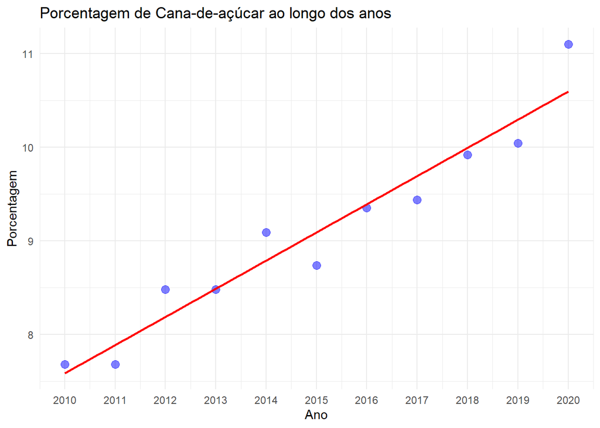

```r
#tabela
tabela_cana <- quant_produzida %>% filter(
  produto == 'Cana-de-açúcar' & microrregiao =='Uberaba (MG)') %>% group_by(produto,microrregiao, ano) %>% summarise(x= sum(x)) %>% arrange(desc(x)) %>% mutate(porcentagem=(x/sum(x))*100) %>%  mutate(porcentagem=round(porcentagem,2))

view(tabela_cana)


grafico_cana2 <- tabela_cana %>%
  ggplot(mapping = aes(x = ano, y = porcentagem)) +
  geom_point(color = 'blue', size = 3, alpha = 0.5) +
  geom_smooth(method = 'lm', se = FALSE, color = 'red') +  # Adiciona linha de regressão
  scale_x_continuous(breaks = seq(min(tabela_cana$ano), max(tabela_cana$ano), by = 1)) +  # Define intervalo dos valores no eixo x
  labs(title = 'Porcentagem de Cana-de-açúcar ao longo dos anos', x = 'Ano', y = 'Porcentagem') +  # Adiciona título e rótulos dos eixos
  theme_minimal()  # Aplica um tema minimalista ao gráfico

print(grafico_cana2)
```